# INFORMALIDAD LABORAL JUVENIL (ENAHO 2023)

[figure not shown]

[figure not shown]

[figure not shown]

[figure not shown]

[figure not shown]

[figure not shown]

[figure not shown]

[figure not shown]

[figure not shown]

[figure not shown]

# Introducción

### Jóvenes encuestados

10230

### Tasa de informalidad

79.7%

### Ingreso promedio

S/ 973

## Rows

### MAPA DEL PERÚ

[interactive chart not shown]

# Variable Dependiente

### Estudio de Caso: Informalidad Juvenil

> *Pregunta de investigación*

> *¿Qué factores socioeconómicos influyen en la probabilidad de que un joven peruano (15-29 años) tenga un empleo informal en 2023?*

> *Hipótesis central*

Los jóvenes con menor nivel educativo, que residen en zonas rurales y la selva, y que no tienen acceso a internet, tienen una probabilidad significativamente mayor de laborar en la informalidad.

### Tabla de Distribución

| Condición | Frecuencia | Porcentaje |
| --- | --- | --- |
| Formal | 2074 | 20.3 |
| Informal | 8156 | 79.7 |

## Column {data-width=500}

### PREVALENCIA DE INFORMALIDAD

[interactive chart not shown]

### BRECHA REGIONAL

[interactive chart not shown]

# `Variables Independientes

## Column {data-width=500}

### Ingresos (S/.)

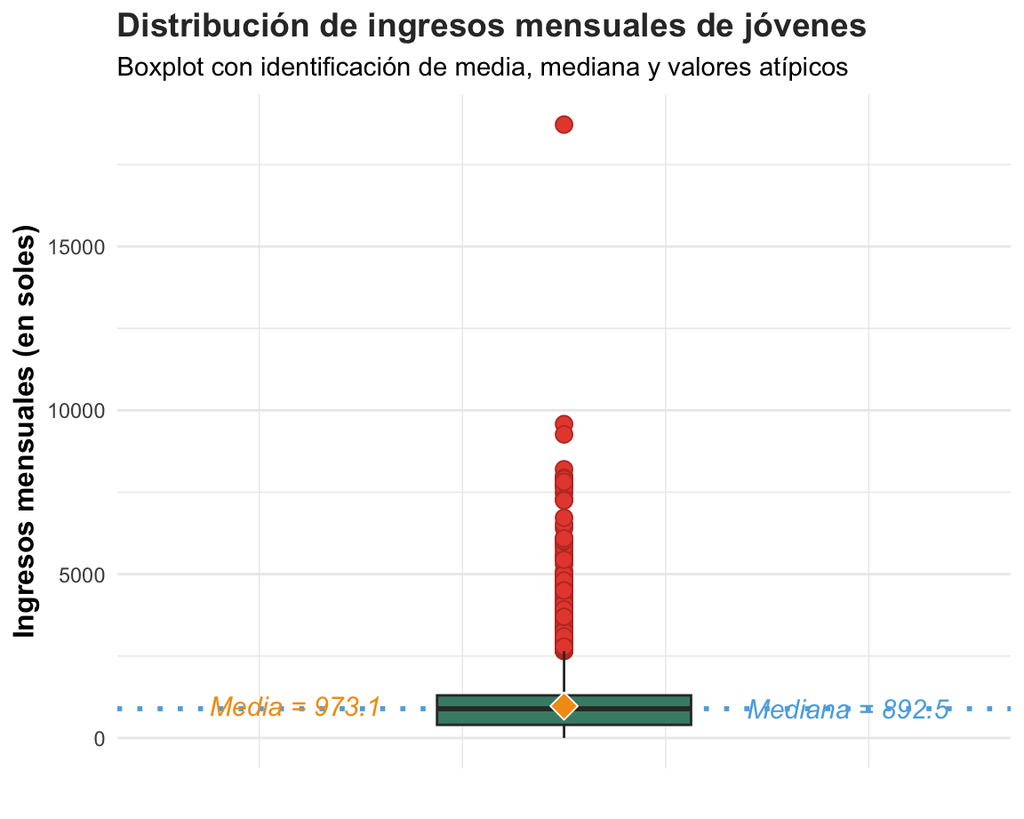

### Edad

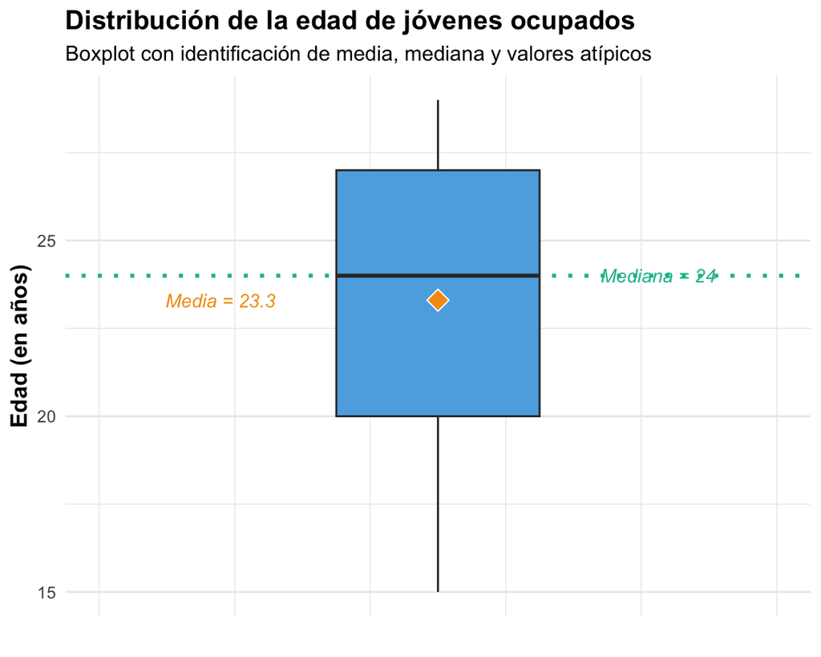

### Antigüedad Laboral

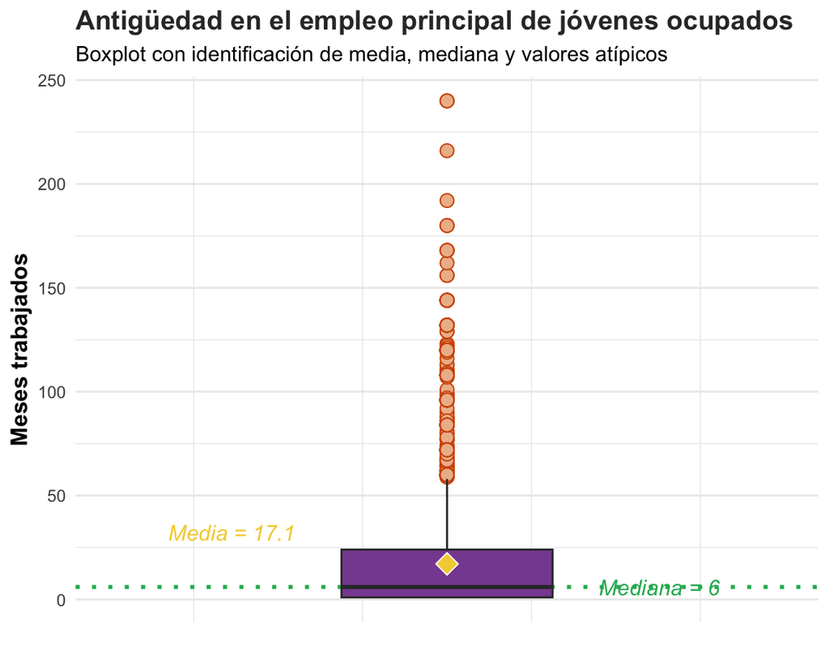

### Sexo

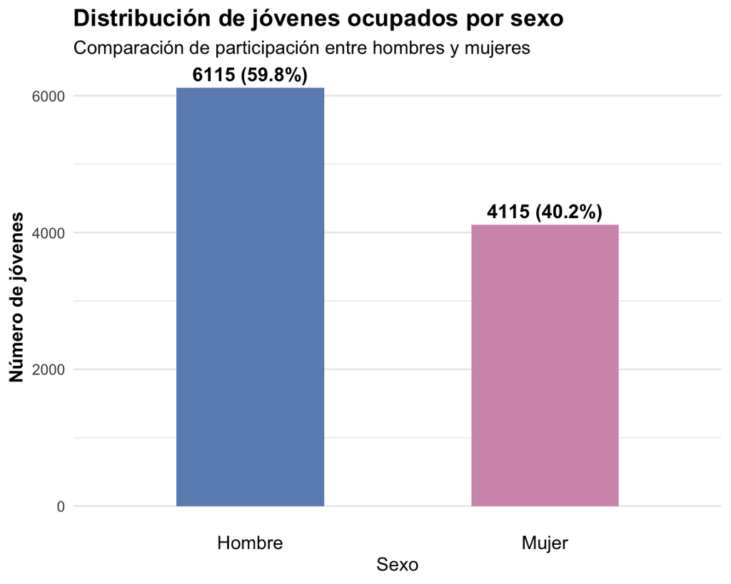

### Nivel Educativo

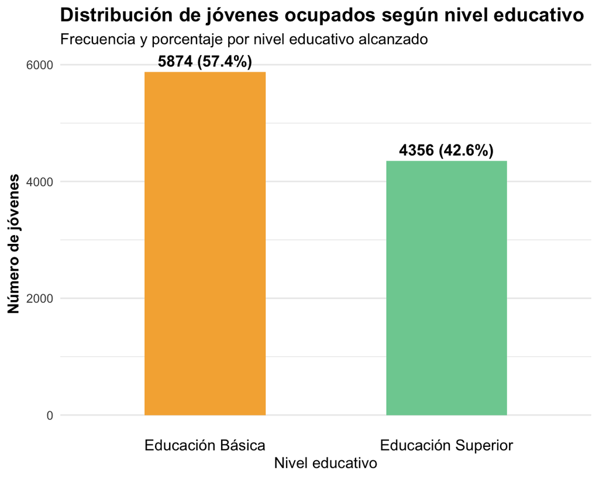

### Región natural

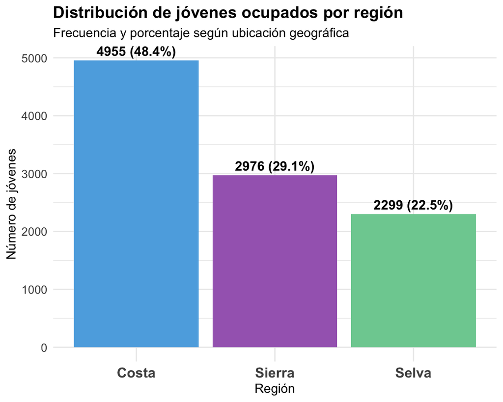

### Acceso a Internet

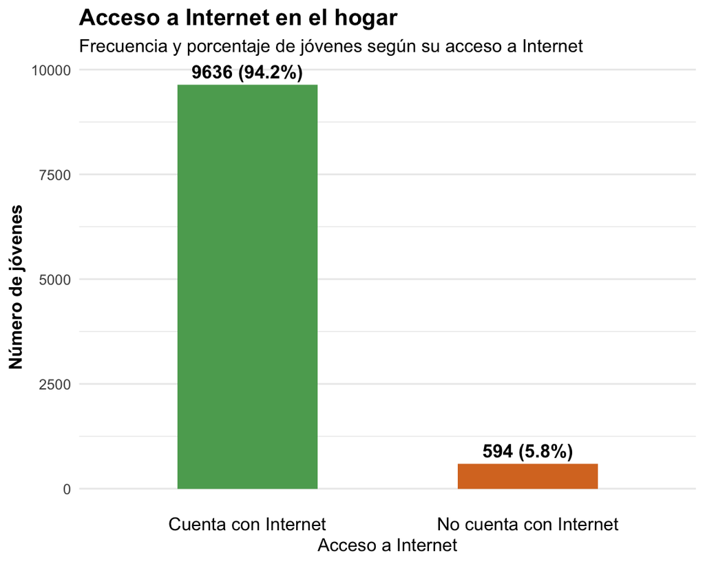

### Estadísticos descripticos de las variables numéricas:

Medidas de tendencia central y dispersión

| Estadístico | Ingreso Mensual (S/.) | Edad (Años) | Antigüedad Laboral (Meses) |
| --- | --- | --- | --- |
| Media | 973.1284 | 23.30235 | 17.12434 |
| Mediana | 892.5 | 24 | 6 |
| SD | 821.9743 | 3.924797 | 25.36264 |
| Min | 1 | 15 | 1 |
| Max | 18720 | 29 | 240 |
| Q1 | 400 | 20 | 1 |
| Q3 | 1300 | 27 | 24 |
| IC | 957.1983, 989.0586 | 23.22628, 23.37841 | 16.63280, 17.61588 |

### Principales hallazgos

- **Precariedad salarial:** La mediana del ingreso mensual es de **S/ 892.50**, cifra que se encuentra **por debajo de la Remuneración Mínima Vital** (S/ 1,025). Esto indica que más de la mitad de los jóvenes ocupados percibe ingresos insuficientes, un rasgo típico de la informalidad.
- **Alta inestabilidad laboral:** Existe una rotación alarmante. La mediana de antigüedad en el empleo es de apenas **6 meses**, mientras que el promedio se dispara a **17.1 meses** debido a valores atípicos. Esto confirma que la gran mayoría de jóvenes tiene empleos temporales o de muy corta duración.
- **Capital humano:** El **57.4%** de la fuerza laboral juvenil cuenta solo con **educación básica**. Este bajo nivel de especialización es una barrera estructural que dificulta el acceso al mercado formal.
- **Brecha digital y regional:** Aunque el **94.2%** tiene acceso a internet (muestra urbana predominante), la concentración del empleo en la **Costa (48.4%)** sugiere una centralización de oportunidades, dejando a la Sierra y Selva con mercados laborales más pequeños.
- **Brecha de género:** La participación laboral es mayoritariamente masculina (**59.8%**), lo que podría evidenciar barreras de entrada para las mujeres jóvenes en el mercado de trabajo.

# Análisis Bivariado

## Column {data-width=500}

### Ingresos vs Informalidad

[interactive chart not shown]

### Edad vs Informalidad

[interactive chart not shown]

### Antigüedad vs Informalidad

[interactive chart not shown]

### Educación vs Informalidad

[interactive chart not shown]

### Sexo vs Informalidad

[interactive chart not shown]

### Región vs Informalidad

[interactive chart not shown]

### Internet vs Informalidad

[interactive chart not shown]

### T-Test:

Comparación de medias e intervalos de confianza (t-test)

| Variable | Media.Formal | Media.Informal | Diferencia | IC.95..Inf | IC.95..Sup | Valor.p |
| --- | --- | --- | --- | --- | --- | --- |
| Ingreso Mensual (S/.) | 1597.36 | 814.39 | 782.97 | 735.39 | 830.54 | <0.001 |
| Edad (Años) | 25.36 | 22.78 | 2.58 | 2.43 | 2.73 | <0.001 |
| Antigüedad (Meses) | 20.21 | 16.34 | 3.87 | 2.71 | 5.04 | <0.001 |

### Principales hallazgos del análisis bivariado

**1. La brecha salarial es estructural y significativa** La prueba T-Student confirma con un nivel de confianza del 99% (p < 0.001) que existe una diferencia abismal en las remuneraciones. Los jóvenes con empleo formal perciben, en promedio, ingresos que casi duplican a los del sector informal. Esto valida que la informalidad en el Perú no es solo una cuestión legal, sino sinónimo de precariedad económica.

**2. El “efecto protector” de la educación superior** El gráfico de barras apiladas revela una relación inversa clara: a mayor nivel educativo, menor es la barra de informalidad. Esto sugiere que la educación superior actúa como un “escudo” contra la informalidad, permitiendo a los jóvenes acceder a mercados laborales más estructurados, aunque no elimina el riesgo por completo.

**3. Inestabilidad y rotación laboral** La diferencia significativa en la antigüedad laboral (meses trabajados) indica que los empleos informales son efímeros. Mientras que el empleo formal tiende a ofrecer mayor estabilidad temporal, el sector informal se caracteriza por una alta rotación, lo que impide a los jóvenes acumular experiencia y antigüedad, perpetuando el ciclo de pobreza.

**4. La brecha digital como segregador social** El acceso a internet muestra una fuerte asociación con la formalidad. Quienes no cuentan con conexión en el hogar presentan tasas de informalidad drásticamente superiores. Esto sugiere que la “desconexión” digital es hoy una barrera de entrada al mercado laboral moderno y formal.

**5. Factor demográfico** La edad promedio de los informales es menor que la de los formales. Esto podría indicar que la informalidad funciona como una “puerta de entrada” al mercado laboral para los más jóvenes (15-19 años) que carecen de experiencia, o bien, que la formalización es un proceso que se alcanza tardíamente.

# Regresión Logística

## Column {data-width=500}

### MATRIZ DE CORRELACIÓN

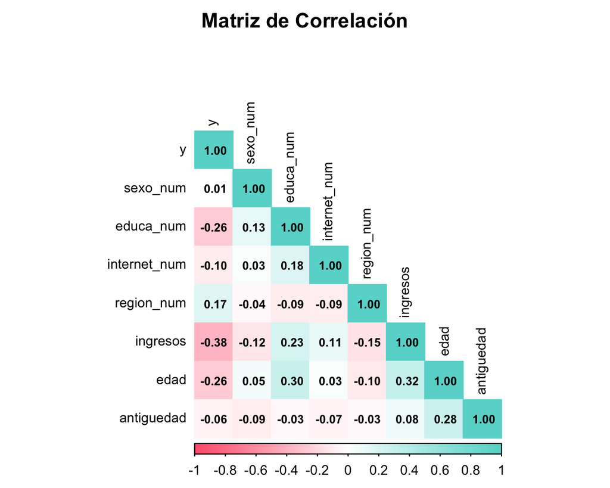

### MODELOS DE REGRESIÓN

Odds Ratios: Probabilidad de Informalidad (Variables numéricas)

|  | Mod 1 (Básico) | &nbsp;Mod 2 (Intermedio) | &nbsp;Mod 3 (Final) |
| --- | --- | --- | --- |
| (Intercept) | 396.727*** | 159.084*** | 397.957*** |
|  | [273.934, 574.561] | [105.201, 240.565] | [216.583, 731.217] |
| sexo_num | 1.104+ | 1.289*** | 0.992 |
|  | [0.997, 1.223] | [1.158, 1.434] | [0.884, 1.114] |
| edad | 0.825*** | 0.847*** | 0.891*** |
|  | [0.813, 0.837] | [0.833, 0.860] | [0.875, 0.907] |
| educa_num |  | 0.337*** | 0.435*** |
|  |  | [0.303, 0.376] | [0.387, 0.489] |
| region_num |  | 1.607*** | 1.513*** |
|  |  | [1.506, 1.715] | [1.414, 1.620] |
| internet_num |  |  | 0.361*** |
|  |  |  | [0.236, 0.552] |
| ingresos |  |  | 0.999*** |
|  |  |  | [0.999, 0.999] |
| antiguedad |  |  | 1.000 |
|  |  |  | [0.997, 1.002] |
| Num.Obs. | 10230 | 10230 | 10230 |
| AIC | 9546.8 | 8894.6 | 8150.9 |
| BIC | 9568.5 | 8930.8 | 8208.7 |
| Log.Lik. | −4770.422 | −4442.295 | −4067.441 |
| F | 329.953 | 275.314 | 207.546 |
| RMSE | 0.39 | 0.37 | 0.36 |

+ p < 0.1, * p < 0.05, ** p < 0.01, *** p < 0.001

### IMPORTANCIA DE VARIABLES (Estandarizado)

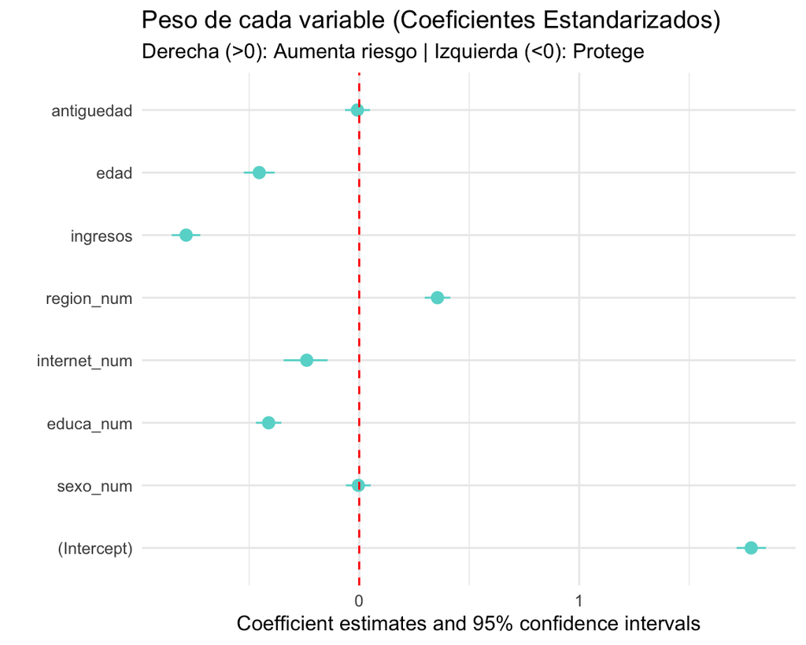

### EVALUACIÓN DEL MODELO FINAL

Precisión Global (Accuracy): 81.5 %

| Prediction | Reference | Real | Pred: Formal | Pred: Informal |
| --- | --- | --- | --- | --- |
| 0 | 0 | Real: Formal | 524 | NA |
| 1 | 0 | Real: Formal | NA | 1550 |
| 0 | 1 | Real: Informal | 342 | NA |
| 1 | 1 | Real: Informal | NA | 7814 |

### CURVA ROC

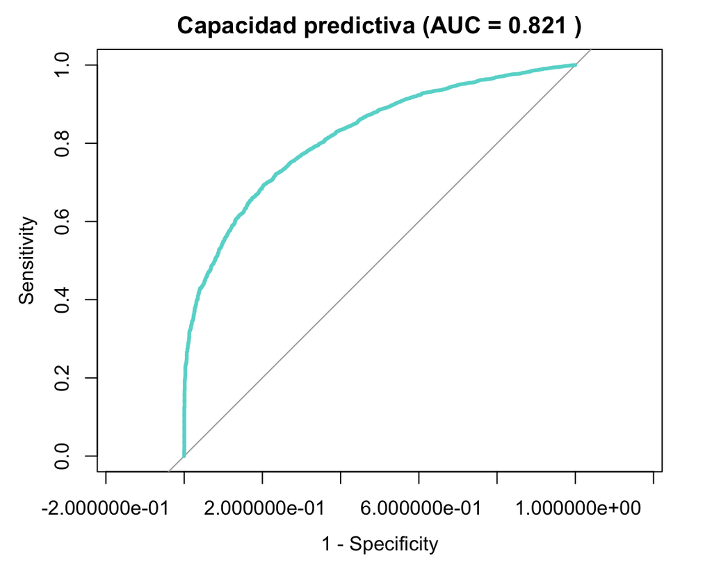

### ¿Qué modelo es el mejor?

Resultados del test LRT

| #Df | LogLik | Df | Chisq | Pr(>Chisq) |
| --- | --- | --- | --- | --- |
| 3 | -4770.422 | NA | NA | NA |
| 5 | -4442.295 | 2 | 656.2540 | 0 |
| 8 | -4067.441 | 3 | 749.7075 | 0 |

### CONSIDERACIONES

````r
---
title: "INFORMALIDAD LABORAL JUVENIL (ENAHO 2023)"
output:
  flexdashboard::flex_dashboard:
    orientation: columns
    vertical_layout: fill
    theme: cerulean
    social: menu
    mathjax: default
    source_code: embed
    navbar:
      - { icon: "fa-brands fa-github", href: "https://github.com/gabidyllic/TrabajoFinal", align: right }
---
<style>
/* 1. Texto gris muy oscuro */
body {
  color: #222222 !important;
}

/* 2. Estilo para las listas y párrafos dentro de los cuadros */
.chart-wrapper .chart-stage p,
.chart-wrapper .chart-stage li,
.chart-wrapper .chart-stage div {
    color: #222222 !important;
    font-weight: 500; /* Texto más grueso */
}

/* 3. Estilo para los títulos de los cuadros (ej: "CONTEXTO") */
.chart-title {
  color: #000000 !important;
  font-weight: bold;
  font-size: 16px;
}

/* 4. Los números grandes de las cajitas de colores */
.value-box .value {
  color: #000000 !important;
}

/* 5. Fondo blanco para contrastar */
body {
  background-color: #ffffff;
}

/* 6. Hover effect para los valueBoxes */
.value-box:hover {
  background-color: #f0f0f0;
  transition: background-color 0.3s ease;
}
</style>

```{r}
# 1. LIBRERÍAS
library(rio)
library(flexdashboard)
library(fontawesome)
library(plotly)
library(DT)
library(dplyr)
library(scales)
library(knitr)
library(kableExtra)
library(ggplot2)
library(tibble)
library(broom)
library(forcats)
library(modelsummary)
library(factoextra)
library(cluster)
library(psych)
library(pROC)
library(caret)
library(tidyverse)

```
```{r}
# 2. CARGA DE DATOS
data <- read.csv("data_jovenes.csv")
```
```{r}
# 3. PALETA DE COLORES
col_rosado <- "#FF637D"
col_turquesa <- "#66D7D1"
col_amarillo <- "#FFF87F"
col_alerta_rojo <- "#e74c3c"
col_verde <- "#2ecc71"
col_azul <- "#3498db"
```

```{r}
# 4. LIMPIEZA Y TRANSFORMACIÓN VISUAL
data <- data %>%
  mutate(
    # Etiquetas para Sexo
    SEXO_LABEL = ifelse(SEXO == 1, "Mujer", "Hombre"),

    # Etiquetas para Informalidad
    INFORMAL_LABEL = ifelse(INFORMAL == 1, "Informal", "Formal"),

    # Etiquetas para Internet
    INTERNET_LABEL = ifelse(INTERNET == 1, "Con Internet", "Sin Internet"),

    # Etiquetas para Educación (Convertimos 1 y 2 a texto)
    EDUCA_LABEL = factor(NIVEL_EDUCATIVO,
                         levels = c(1, 2),
                         labels = c("Educación Básica", "Educación Superior")),

    REGION = as.factor(REGION)
  )
```


```{r}
#  5. PREPARACIÓN NUMÉRICA PARA EFA

# A) Región: Convertimos Costa/Sierra/Selva a 1, 2, 3
data$REGION_NUM <- as.numeric(data$REGION)

# B) Educación: Ya viene como 1 y 2, nos aseguramos que sea numérico
data$EDUCA_NUM <- as.numeric(data$NIVEL_EDUCATIVO)

# C) Sexo: Ya viene como 1 y 0 (o 1 y 2), nos aseguramos que sea numérico
data$SEXO_NUM <- as.numeric(data$SEXO)

# D) Internet: Ya viene como 1 y 0
data$INTERNET_NUM <- as.numeric(data$INTERNET)

# E) Ingresos y Antigüedad: Ya son numéricos

# Seleccionamos las columnas finales para el EFA y las estandarizamos (scale) para que los sueldos (miles) no opaquen a la educación (1 o 2).
data_efa <- data %>%
  select(ingresos_jovenes, mesestrab_antiguedad, EDAD,
         REGION_NUM, EDUCA_NUM, SEXO_NUM, INTERNET_NUM) %>%
  na.omit() %>%
  scale()
```

Introducción {data-icon="fa-regular fa-id-card" style="color: #f7f7f7;"}
=====================================

Column {data-width=400}
-----------------------------------------------------------------------

### Jóvenes encuestados

```{r}
total <- nrow(data)
valueBox(
  value = total,
  caption = "Jóvenes encuestados",
  icon = "fas fa-users",
  color = col_turquesa
)
```


### Tasa de informalidad

```{r}
informales_count <- sum(data$INFORMAL == 1, na.rm = TRUE)
tasa <- round((informales_count / total) * 100, 1)

valueBox(
  value = paste0(tasa, "%"),
  caption = "Tasa de informalidad laboral",
  icon = "fas fa-briefcase",
  color = ifelse(tasa > 70, col_alerta_rojo, col_amarillo)
)
```

### Ingreso promedio

```{r}
ingreso_prom <- round(mean(data$ingresos_jovenes, na.rm = TRUE), 0)
valueBox(
  value = paste("S/", ingreso_prom),
  caption = "Ingreso mensual promedio",
  icon = "fas fa-money-bill-wave",
  color = col_rosado
)
```

### CONTEXTO: {data-height=400}


- **Problemática actual:** La informalidad laboral en jóvenes (15-29 años) es una barrera persistente para el desarrollo económico y la protección social en el Perú.

- **El estudio utiliza la Encuesta Nacional de Hogares para analizar una muestra representativa a nivel nacional.**

- **Objetivo del estudio:** Identificar qué factores socioeconómicos incrementan la probabilidad de que un joven tenga un empleo informal.

- **Metodología:** Se aplican técnicas descriptivas, modelos de regresión logística y análisis multivariado (Factorial y Clúster) para entender los perfiles de informalidad.

Rows
-----------------------------------------------------------------------
### MAPA DEL PERÚ

```{r}
# 6. MAPA DEL PERÚ
library(leaflet)

# Crear mapa base de Perú
mapa_peru <- leaflet() %>%
  addTiles() %>%
  addMarkers(lng = -75.03, lat = -9.19, popup = "Lima")

mapa_peru
```
Variable Dependiente {data-icon="fa-solid fa-layer-group"}
=====================================

Column {data-width=500}
-----------------------------------------------------------------------

### Estudio de Caso: Informalidad Juvenil

> ***Pregunta de investigación***

> ***¿Qué factores socioeconómicos influyen en la probabilidad de que un joven peruano (15-29 años) tenga un empleo informal en 2023?***

> ***Hipótesis central***

Los jóvenes con menor nivel educativo, que residen en zonas rurales y la selva, y que no tienen acceso a internet, tienen una probabilidad significativamente mayor de laborar en la informalidad.

### Tabla de Distribución {data-height=300}

```{r}
tabla_dep <- data %>%
  count(INFORMAL_LABEL) %>%
  mutate(
    Porcentaje = round(100 * n / sum(n), 1)
  ) %>%
  select(Condición = INFORMAL_LABEL, Frecuencia = n, Porcentaje)

datatable(tabla_dep,
          options = list(dom = 't', pageLength = 5),
          caption = 'Distribución de jóvenes según Condición Laboral',
          rownames = FALSE)
```
````

````r
Column {data-width=500} {.tabset}
-----------------------------------------------------------------------

### PREVALENCIA DE INFORMALIDAD

```{r}
p_barras <- data %>%
  count(INFORMAL_LABEL) %>%
  mutate(
    pct = round(n / sum(n) * 100, 1),
    etiqueta = paste0(n, "\n(", pct, "%)")
  ) %>%
  ggplot(aes(x = INFORMAL_LABEL, y = n, fill = INFORMAL_LABEL)) +
  geom_col(width = 0.6) +

  scale_fill_manual(values = c(col_turquesa, col_rosado)) +
  geom_text(aes(label = etiqueta), vjust = -0.5, fontface = "bold") +
  labs(
    title = "Distribución de empleo formal e informal",
    subtitle = "Muestra ENAHO 2023",
    x = "Tipo de empleo",
    y = "Cantidad de jóvenes",
    caption = "Encuesta Nacional de Hogares (ENAHO) - 2023, INEI Perú. Elaboración propia."
  ) +
  theme_minimal() +
  theme(legend.position = "none")


ggplotly(p_barras, tooltip = c("y"))
```

### BRECHA REGIONAL

```{r}
p_regiones <- data %>%
  filter(!is.na(REGION)) %>%
  count(REGION, INFORMAL_LABEL) %>%
  group_by(REGION) %>%
  mutate(pct = round(n/sum(n)*100, 1)) %>%
  ggplot(aes(x = REGION, y = pct, fill = INFORMAL_LABEL)) +
  geom_col(position = "dodge") +
  scale_fill_manual(values = c(col_turquesa, col_rosado)) +
  labs(
    title = "Informalidad según región",
    y = "Porcentaje (%)",
    x = "Región",
    fill = "Condición"
  ) +
  theme_minimal()

ggplotly(p_regiones)
```

`Variables Independientes {data-icon="fa-solid fa-code-branch"}
=====================================

Column {data-width=500} {.tabset}
-----------------------------------------------------------------------

### Ingresos (S/.)

```{r}
# 1. Calculamos valores exactos
media_ing <- round(mean(data$ingresos_jovenes, na.rm = TRUE), 1)
mediana_ing <- median(data$ingresos_jovenes, na.rm = TRUE)

# 2. Gráfico Boxplot Verde Oscuro con Outliers Rojos
g_ingreso <- ggplot(data, aes(x = 0, y = ingresos_jovenes)) +

  # A) Línea punteada Azul (Mediana) atravesando todo
  geom_hline(yintercept = mediana_ing, linetype = "dotted", color = "#5DADE2", size = 1) +

  # B) El Boxplot (Caja Verde Oscuro)
  # Configuramos los outliers (puntos) para que sean ROJOS como en tu foto
  geom_boxplot(fill = "#458B74", width = 0.25,
               outlier.colour = "#C0392B", outlier.fill = "#E74C3C",
               outlier.shape = 21, outlier.size = 3) +

  # C) El Rombo Naranja (La Media)
  stat_summary(fun = mean, geom = "point", shape = 23, size = 4, fill = "#F39C12", color = "white") +

  # D) Texto flotante a la izquierda (Media) - Naranja
  annotate("text", x = -0.18, y = media_ing,
           label = paste("Media =", media_ing),
           color = "#F39C12", fontface = "italic", size = 4, hjust = 1) +

  # E) Texto flotante a la derecha (Mediana) - Azul Claro
  annotate("text", x = 0.18, y = mediana_ing,
           label = paste("Mediana =", mediana_ing),
           color = "#5DADE2", fontface = "italic", size = 4, hjust = 0) +

  # F) Títulos exactos
  labs(
    title = "Distribución de ingresos mensuales de jóvenes",
    subtitle = "Boxplot con identificación de media, mediana y valores atípicos",
    x = "",
    y = "Ingresos mensuales (en soles)"
  ) +

  # G) Tema limpio
  theme_minimal() +
  theme(
    plot.title = element_text(face = "bold", size = 14, color = "#333333"),
    axis.title.y = element_text(face = "bold", size = 12),
    axis.text.x = element_blank(),  # Sin texto en eje X
    panel.grid.major.x = element_blank()
  ) +
  # Fijamos límites
  xlim(-0.4, 0.4)

# Mostramos versión estática
g_ingreso
```

### Edad

```{r}
# 1. Calculamos valores
media_edad <- round(mean(data$EDAD, na.rm = TRUE), 1)
mediana_edad <- median(data$EDAD, na.rm = TRUE)

# 2. Gráfico "Slim"
g_edad <- ggplot(data, aes(x = 0, y = EDAD)) +

  # Línea de referencia
  geom_hline(yintercept = mediana_edad, linetype = "dotted", color = "#1ABC9C", size = 1) +

  # AQUI ESTÁ EL CAMBIO: width = 0.15 (Mucho más delgado)
  geom_boxplot(fill = "#5DADE2", width = 0.15, outlier.shape = 1) +

  # Rombo
  stat_summary(fun = mean, geom = "point", shape = 23, size = 4, fill = "#F39C12", color = "white") +

  # Textos ajustados (acercamos las coordenadas x al centro)
  annotate("text", x = -0.12, y = media_edad,
           label = paste("Media =", media_edad),
           color = "#F39C12", fontface = "italic", size = 3.5, hjust = 1) +

  annotate("text", x = 0.12, y = mediana_edad,
           label = paste("Mediana =", mediana_edad),
           color = "#1ABC9C", fontface = "italic", size = 3.5, hjust = 0) +

  labs(
    title = "Distribución de la edad de jóvenes ocupados",
    subtitle = "Boxplot con identificación de media, mediana y valores atípicos",
    x = "",
    y = "Edad (en años)"
  ) +

  theme_minimal() +
  theme(
    plot.title = element_text(face = "bold", size = 14),
    axis.title.y = element_text(face = "bold", size = 12),
    axis.text.x = element_blank(),
    panel.grid.major.x = element_blank()
  ) +
  # Fijamos límites en X para que la caja no se estire
  xlim(-0.25, 0.25)

g_edad
```


### Antigüedad Laboral

```{r}
# 1. Calculamos valores exactos
media_ant <- round(mean(data$mesestrab_antiguedad, na.rm = TRUE), 1)
mediana_ant <- median(data$mesestrab_antiguedad, na.rm = TRUE)

# 2. Gráfico Boxplot Morado con Outliers Naranjas
g_antiguedad <- ggplot(data, aes(x = 0, y = mesestrab_antiguedad)) +

  # A) Línea punteada verde (Mediana) atravesando todo
  geom_hline(yintercept = mediana_ant, linetype = "dotted", color = "#28B463", size = 1) +

  # B) El Boxplot (Caja Morada)
  # Configuramos los outliers (puntos) para que sean naranjas y grandes como en tu foto
  geom_boxplot(fill = "#884EA0", width = 0.25,
               outlier.colour = "#D35400", outlier.fill = "#EDBB99",
               outlier.shape = 21, outlier.size = 3) +

  # C) El Rombo Amarillo (La Media)
  stat_summary(fun = mean, geom = "point", shape = 23, size = 4, fill = "#F4D03F", color = "white") +

  # D) Texto flotante a la izquierda (Media) - Amarillo
  # Ajustamos la posición 'y' un poco para que no se superponga
  annotate("text", x = -0.18, y = media_ant + 15,
           label = paste("Media =", media_ant),
           color = "#F4D03F", fontface = "italic", size = 4, hjust = 1) +
````

````r
  # E) Texto flotante a la derecha (Mediana) - Verde
  annotate("text", x = 0.18, y = mediana_ant,
           label = paste("Mediana =", mediana_ant),
           color = "#28B463", fontface = "italic", size = 4, hjust = 0) +

  # F) Títulos exactos
  labs(
    title = "Antigüedad en el empleo principal de jóvenes ocupados",
    subtitle = "Boxplot con identificación de media, mediana y valores atípicos",
    x = "",
    y = "Meses trabajados"
  ) +

  # G) Tema limpio
  theme_minimal() +
  theme(
    plot.title = element_text(face = "bold", size = 14, color = "#333333"),
    axis.title.y = element_text(face = "bold", size = 12),
    axis.text.x = element_blank(),  # Sin texto en eje X
    panel.grid.major.x = element_blank()
  ) +
  # Fijamos límites para centrar la caja delgada
  xlim(-0.4, 0.4)

# Mostramos versión estática
g_antiguedad
```

### Sexo

```{r}
# 1. Preparar datos (Conteo y Porcentaje)
data_sexo_plot <- data %>%
  count(SEXO_LABEL) %>%
  mutate(
    pct = round(n / sum(n) * 100, 1),
    # Etiqueta combinada: "6115 (59.8%)"
    etiqueta = paste0(n, " (", pct, "%)")
  )

# 2. Crear el gráfico idéntico a tu captura
g_sexo <- ggplot(data_sexo_plot, aes(x = SEXO_LABEL, y = n, fill = SEXO_LABEL)) +
  geom_col(width = 0.5) + # Ancho ajustado

  # Etiquetas encima de las barras
  geom_text(aes(label = etiqueta), vjust = -0.5, fontface = "bold", size = 4) +

  # Colores personalizados:
  scale_fill_manual(values = c("#6A8EBF", "#D499B9")) +

  # Títulos exactos de tu imagen
  labs(
    title = "Distribución de jóvenes ocupados por sexo",
    subtitle = "Comparación de participación entre hombres y mujeres",
    x = "Sexo",
    y = "Número de jóvenes"
  ) +

  # Tema limpio
  theme_minimal() +
  theme(
    legend.position = "none",
    plot.title = element_text(face = "bold", size = 14),
    axis.text.x = element_text(size = 11, color = "black"),
    axis.title.y = element_text(face = "bold"),
    panel.grid.major.x = element_blank()
  )

# Mostramos versión estática para mantener el diseño exacto
g_sexo
```

### Nivel Educativo

```{r}
# 1. Preparar datos (Conteo y Porcentaje)
data_educ_plot <- data %>%
  count(EDUCA_LABEL) %>%
  mutate(
    pct = round(n / sum(n) * 100, 1),
    # Etiqueta combinada: "5874 (57.4%)"
    etiqueta = paste0(n, " (", pct, "%)")
  )

# 2. Crear el gráfico idéntico a tu captura
g_educa <- ggplot(data_educ_plot, aes(x = EDUCA_LABEL, y = n, fill = EDUCA_LABEL)) +
  geom_col(width = 0.5) + # Ajustamos el ancho para que no sean muy gordas

  # Etiquetas encima de las barras
  geom_text(aes(label = etiqueta), vjust = -0.5, fontface = "bold", size = 4) +

  scale_fill_manual(values = c("#F5B041", "#7DCEA0")) +

  # Títulos exactos de tu imagen
  labs(
    title = "Distribución de jóvenes ocupados según nivel educativo",
    subtitle = "Frecuencia y porcentaje por nivel educativo alcanzado",
    x = "Nivel educativo",
    y = "Número de jóvenes"
  ) +


  theme_minimal() +
  theme(
    legend.position = "none",
    plot.title = element_text(face = "bold", size = 14),
    axis.text.x = element_text(size = 11, color = "black"),
    axis.title.y = element_text(face = "bold"),
    panel.grid.major.x = element_blank()
  )

# Mostramos versión estática para mantener el diseño exacto
g_educa
```

### Región natural

```{r}
# 1. Preparamos los datos con la etiqueta exacta
data_region_plot <- data %>%
  count(REGION) %>%
  mutate(
    pct = round(n / sum(n) * 100, 1),
    etiqueta = paste0(n, " (", pct, "%)"),
    REGION = reorder(REGION, -n)
  )

# 2. Creamos el gráfico
g_region <- ggplot(data_region_plot, aes(x = REGION, y = n, fill = REGION)) +
  geom_col() +

  # Ponemos los textos encima de las barras
  geom_text(aes(label = etiqueta), vjust = -0.5, fontface = "bold", size = 4) +

  # Usamos colores parecidos a tu imagen (Azul, Morado, Verde)
  scale_fill_manual(values = c("#5DADE2", "#A569BD", "#7DCEA0")) +

  # Títulos exactos de tu imagen
  labs(
    title = "Distribución de jóvenes ocupados por región",
    subtitle = "Frecuencia y porcentaje según ubicación geográfica",
    x = "Región",
    y = "Número de jóvenes"
  ) +

  theme_minimal() +
  theme(
    legend.position = "none",
    plot.title = element_text(face = "bold", size = 14),
    axis.text.y = element_text(size = 10),
    axis.text.x = element_text(size = 12, face = "bold")
  )

g_region
```

### Acceso a Internet

```{r}
# 1. Preparar datos
data_net_plot <- data %>%
  count(INTERNET_LABEL) %>%
  mutate(
    pct = round(n / sum(n) * 100, 1),
    etiqueta = paste0(n, " (", pct, "%)"),


    Etiqueta_Foto = case_when(
       INTERNET_LABEL == "Sin Internet" ~ "No cuenta con Internet",
       INTERNET_LABEL == "Con Internet" ~ "Cuenta con Internet",
       TRUE ~ INTERNET_LABEL
    )
  )

# 2. Crear el gráfico idéntico a tu captura
g_net <- ggplot(data_net_plot, aes(x = Etiqueta_Foto, y = n, fill = Etiqueta_Foto)) +
  geom_col(width = 0.5) + # Barras delgadas

  # Etiquetas encima
  geom_text(aes(label = etiqueta), vjust = -0.5, fontface = "bold", size = 4) +

  # Colores de tu foto: Naranja quemado y Verde hoja
  scale_fill_manual(values = c("No cuenta con Internet" = "#D97728",
                               "Cuenta con Internet" = "#5BA85F")) +

  # Títulos exactos
  labs(
    title = "Acceso a Internet en el hogar",
    subtitle = "Frecuencia y porcentaje de jóvenes según su acceso a Internet",
    x = "Acceso a Internet",
    y = "Número de jóvenes"
  ) +

  # Tema limpio
  theme_minimal() +
  theme(
    legend.position = "none",
    plot.title = element_text(face = "bold", size = 14),
    axis.text.x = element_text(size = 11, color = "black"),
    axis.title.y = element_text(face = "bold"),
    panel.grid.major.x = element_blank()
  )

# Versión estática para mantener el diseño perfecto
g_net
```

Column {data-width=500}
-----------------------------------------------------------------------

### Estadísticos descripticos de las variables numéricas:

```{r}
# 1. Seleccionar solo las variables numéricas
vars_numericas <- data %>%
 dplyr::select(
    `Ingreso Mensual (S/.)` = ingresos_jovenes,
    `Edad (Años)` = EDAD,
    `Antigüedad Laboral (Meses)` = mesestrab_antiguedad
  ) %>%
  na.omit()
````

````r
# 2. Calcular resumen estadístico COMPLETO
resumen_multi <- vars_numericas %>%
  summarise(across(everything(), list(
    Media = ~mean(., na.rm = TRUE),
    Mediana = ~median(., na.rm = TRUE),
    SD = ~sd(., na.rm = TRUE),
    Min = ~min(., na.rm = TRUE),
    Max = ~max(., na.rm = TRUE),
    Q1 = ~quantile(., 0.25, na.rm = TRUE),
    Q3 = ~quantile(., 0.75, na.rm = TRUE),
    IC_inf = ~mean(., na.rm = TRUE) - qt(0.975, sum(!is.na(.)) - 1) * sd(., na.rm = TRUE) / sqrt(sum(!is.na(.))),
    IC_sup = ~mean(., na.rm = TRUE) + qt(0.975, sum(!is.na(.)) - 1) * sd(., na.rm = TRUE) / sqrt(sum(!is.na(.)))
  ), .names = "{.col}_{.fn}")) %>%
  pivot_longer(everything(), names_to = c("Variable", "Estadístico"), names_sep = "_", values_to = "Valor") %>%

  # --- VOLVEMOS A LA ORIENTACIÓN ORIGINAL ---
  # Variables como columnas (arriba), Estadísticos como filas (izquierda)
  pivot_wider(names_from = Variable, values_from = Valor) %>%
  rename(`Estadístico` = Estadístico)

# 3. Mostrar tabla
resumen_multi %>%
  kable(digits = 1, caption = "Medidas de tendencia central y dispersión") %>%
  kable_styling(
    bootstrap_options = c("striped", "hover", "condensed"),
    full_width = FALSE,
    position = "center",
    font_size = 14
  ) %>%
  row_spec(0, bold = TRUE) # Negrita en los encabezados
```
### Principales hallazgos {data-height=300}

- **Precariedad salarial:** La mediana del ingreso mensual es de **S/ 892.50**, cifra que se encuentra **por debajo de la Remuneración Mínima Vital** (S/ 1,025). Esto indica que más de la mitad de los jóvenes ocupados percibe ingresos insuficientes, un rasgo típico de la informalidad.

- **Alta inestabilidad laboral:** Existe una rotación alarmante. La mediana de antigüedad en el empleo es de apenas **6 meses**, mientras que el promedio se dispara a **17.1 meses** debido a valores atípicos. Esto confirma que la gran mayoría de jóvenes tiene empleos temporales o de muy corta duración.

- **Capital humano:** El **57.4%** de la fuerza laboral juvenil cuenta solo con **educación básica**. Este bajo nivel de especialización es una barrera estructural que dificulta el acceso al mercado formal.

- **Brecha digital y regional:** Aunque el **94.2%** tiene acceso a internet (muestra urbana predominante), la concentración del empleo en la **Costa (48.4%)** sugiere una centralización de oportunidades, dejando a la Sierra y Selva con mercados laborales más pequeños.

- **Brecha de género:** La participación laboral es mayoritariamente masculina (**59.8%**), lo que podría evidenciar barreras de entrada para las mujeres jóvenes en el mercado de trabajo.

Análisis Bivariado {data-icon="fa-solid fa-chart-line"}
=====================================

Column {data-width=500} {.tabset}
-----------------------------------------------------------------------

### Ingresos vs Informalidad

```{r}
# Cálculo de Medias e Intervalos
g_ingreso <- data %>%
  group_by(INFORMAL_LABEL) %>%
  summarise(
    Media = mean(ingresos_jovenes, na.rm = TRUE),
    SD = sd(ingresos_jovenes, na.rm = TRUE),
    N = n(),
    SE = SD / sqrt(N),
    IC_Inf = Media - 1.96 * SE,
    IC_Sup = Media + 1.96 * SE
  )

p_bivar1 <- ggplot(g_ingreso, aes(x = INFORMAL_LABEL, y = Media)) +
  geom_bar(stat = "identity", aes(fill = INFORMAL_LABEL), color = "black", width = 0.6) +
  scale_fill_manual(values = c(col_turquesa, col_rosado)) +
  geom_errorbar(aes(ymin = IC_Inf, ymax = IC_Sup), width = 0.2) +
  geom_text(aes(label = paste("S/.", round(Media, 0)), y = Media),
            vjust = 2.5, fontface = "bold", color = "black") +
  labs(title = "Ingreso promedio según condición laboral", y = "Soles (S/.)", x = "Condición laboral") +
  theme_minimal() + theme(legend.position = "none")

ggplotly(p_bivar1)
```

### Edad vs Informalidad

```{r}
g_edad <- data %>%
  group_by(INFORMAL_LABEL) %>%
  summarise(
    Media = mean(EDAD, na.rm = TRUE),
    SD = sd(EDAD, na.rm = TRUE),
    N = n(),
    SE = SD / sqrt(N),
    IC_Inf = Media - 1.96 * SE,
    IC_Sup = Media + 1.96 * SE
  )

p_bivar2 <- ggplot(g_edad, aes(x = INFORMAL_LABEL, y = Media)) +
  geom_bar(stat = "identity", aes(fill = INFORMAL_LABEL), color = "black", width = 0.6) +
  scale_fill_manual(values = c(col_turquesa, col_rosado)) +
  geom_errorbar(aes(ymin = IC_Inf, ymax = IC_Sup), width = 0.2) +
  geom_text(aes(label = paste(round(Media, 1), "años"), y = Media),
            vjust = 2.5, fontface = "bold", color = "black") +
  labs(title = "Edad promedio según condición", y = "Edad (años)", x = "Condición laboral") +
  theme_minimal() + theme(legend.position = "none")

ggplotly(p_bivar2)
```

### Antigüedad vs Informalidad

```{r}
g_ant <- data %>%
  group_by(INFORMAL_LABEL) %>%
  summarise(
    Media = mean(mesestrab_antiguedad, na.rm = TRUE),
    SD = sd(mesestrab_antiguedad, na.rm = TRUE),
    N = n(),
    SE = SD / sqrt(N),
    IC_Inf = Media - 1.96 * SE,
    IC_Sup = Media + 1.96 * SE
  )

p_bivar3 <- ggplot(g_ant, aes(x = INFORMAL_LABEL, y = Media)) +
  geom_bar(stat = "identity", aes(fill = INFORMAL_LABEL), color = "black", width = 0.6) +
  scale_fill_manual(values = c(col_turquesa, col_rosado)) +
  geom_errorbar(aes(ymin = IC_Inf, ymax = IC_Sup), width = 0.2) +
  geom_text(aes(label = paste(round(Media, 1), "m"), y = Media),
            vjust = 2.5, fontface = "bold", color = "black") +
  labs(title = "Antigüedad promedio (Meses)", y = "Meses", x = "Condición laboral") +
  theme_minimal() + theme(legend.position = "none")

ggplotly(p_bivar3)
```

### Educación vs Informalidad

```{r}
# Gráfico de barras apiladas 100%
p_educ <- data %>%
  count(EDUCA_LABEL, INFORMAL_LABEL) %>%
  group_by(EDUCA_LABEL) %>%
  mutate(pct = n / sum(n)) %>%
  ggplot(aes(x = EDUCA_LABEL, y = n, fill = INFORMAL_LABEL)) +
  geom_col(position = "fill") +
  scale_y_continuous(labels = scales::percent) +
  scale_fill_manual(values = c(col_turquesa, col_rosado)) +
  labs(title = "¿La educación reduce la informalidad?", x = "", y = "Proporción", fill = "Condición laboral") +
  theme_minimal() +
  coord_flip() # Horizontal para leer mejor
````

````r
ggplotly(p_educ)
```

### Sexo vs Informalidad

```{r}
p_sex <- data %>%
  count(SEXO_LABEL, INFORMAL_LABEL) %>%
  group_by(SEXO_LABEL) %>%
  mutate(pct = n / sum(n)) %>%
  ggplot(aes(x = SEXO_LABEL, y = n, fill = INFORMAL_LABEL)) +
  geom_col(position = "fill") +
  scale_y_continuous(labels = scales::percent) +
  scale_fill_manual(values = c(col_turquesa, col_rosado)) +
  labs(title = "Disparidad por género", x = "Sexo", y = "Proporción", fill = "Condición laboral") +
  theme_minimal()

ggplotly(p_sex)
```

### Región vs Informalidad

```{r}
p_reg <- data %>%
  count(REGION, INFORMAL_LABEL) %>%
  group_by(REGION) %>%
  mutate(pct = n / sum(n)) %>%
  ggplot(aes(x = REGION, y = n, fill = INFORMAL_LABEL)) +
  geom_col(position = "fill") +
  scale_y_continuous(labels = scales::percent) +
  scale_fill_manual(values = c(col_turquesa, col_rosado)) +
  labs(title = "Informalidad por región natural", x = "", y = "Proporción", fill = "Condición laboral") +
  theme_minimal() +
  coord_flip()

ggplotly(p_reg)
```

### Internet vs Informalidad

```{r}
p_net <- data %>%
  count(INTERNET_LABEL, INFORMAL_LABEL) %>%
  group_by(INTERNET_LABEL) %>%
  mutate(pct = n / sum(n)) %>%
  ggplot(aes(x = INTERNET_LABEL, y = n, fill = INFORMAL_LABEL)) +
  geom_col(position = "fill") +
  scale_y_continuous(labels = scales::percent) +
  scale_fill_manual(values = c(col_turquesa, col_rosado)) +
  labs(title = "Brecha digital", x = "Acceso a Internet", y = "Proporción", fill = "Condición laboral") +
  theme_minimal()

ggplotly(p_net)
```

Column {data-width=600}
-----------------------------------------------------------------------

### T-Test: {data-height=400}

```{r}
### Prueba T-Student (Diferencia de Medias)

# 1. Variables numéricas que SÍ tienes en tu data
vars_test <- c("ingresos_jovenes", "EDAD", "mesestrab_antiguedad")
nombres_bonitos <- c("Ingreso Mensual (S/.)", "Edad (Años)", "Antigüedad (Meses)")

# 2. Función T-test incluyendo los Intervalos de Confianza (IC)
resultados_t <- map2_df(vars_test, nombres_bonitos, function(var, nombre) {
  t <- t.test(data[[var]] ~ data$INFORMAL_LABEL)

  data.frame(
    Variable = nombre,
    `Media Formal` = round(t$estimate[1], 2),
    `Media Informal` = round(t$estimate[2], 2),
    # Agregamos la Diferencia
    `Diferencia` = round(t$estimate[1] - t$estimate[2], 2),
    # Agregamos los Intervalos de Confianza de la diferencia
    `IC 95% Inf` = round(t$conf.int[1], 2),
    `IC 95% Sup` = round(t$conf.int[2], 2),
    `Valor p` = format.pval(t$p.value, digits = 3, eps = 0.001)
  )
})

# 3. Tabla completa
resultados_t %>%
  kable(format = "html", row.names = FALSE, caption = "Comparación de medias e intervalos de confianza (t-test)", align = "c") %>%
  kable_styling(
    bootstrap_options = c("striped", "hover", "condensed"),
    full_width = FALSE,
    position = "center",
    font_size = 13 # Un poquito más chica para que entren todas las columnas
  ) %>%
  row_spec(which(resultados_t$`Valor p` < 0.05), bold = TRUE, color = "black", background = "#dff0d8")
```

### Principales hallazgos del análisis bivariado

**1. La brecha salarial es estructural y significativa**
La prueba T-Student confirma con un nivel de confianza del 99% (p < 0.001) que existe una diferencia abismal en las remuneraciones. Los jóvenes con empleo formal perciben, en promedio, ingresos que casi duplican a los del sector informal. Esto valida que la informalidad en el Perú no es solo una cuestión legal, sino sinónimo de precariedad económica.

**2. El "efecto protector" de la educación superior**
El gráfico de barras apiladas revela una relación inversa clara: a mayor nivel educativo, menor es la barra de informalidad. Esto sugiere que la educación superior actúa como un "escudo" contra la informalidad, permitiendo a los jóvenes acceder a mercados laborales más estructurados, aunque no elimina el riesgo por completo.

**3. Inestabilidad y rotación laboral**
La diferencia significativa en la antigüedad laboral (meses trabajados) indica que los empleos informales son efímeros. Mientras que el empleo formal tiende a ofrecer mayor estabilidad temporal, el sector informal se caracteriza por una alta rotación, lo que impide a los jóvenes acumular experiencia y antigüedad, perpetuando el ciclo de pobreza.

**4. La brecha digital como segregador social**
El acceso a internet muestra una fuerte asociación con la formalidad. Quienes no cuentan con conexión en el hogar presentan tasas de informalidad drásticamente superiores. Esto sugiere que la "desconexión" digital es hoy una barrera de entrada al mercado laboral moderno y formal.

**5. Factor demográfico**
La edad promedio de los informales es menor que la de los formales. Esto podría indicar que la informalidad funciona como una "puerta de entrada" al mercado laboral para los más jóvenes (15-19 años) que carecen de experiencia, o bien, que la formalización es un proceso que se alcanza tardíamente.

Regresión Logística {data-icon="fa-solid fa-calculator"}
=====================================

```{r}
# 1. PREPARACIÓN DE DATOS: TODO A NUMÉRICO
# Siguiendo la instrucción de tu profesora, convertimos factores a números.
data_reg <- data %>%
  mutate(
    # --- VARIABLE DEPENDIENTE (Y) ---
    # 1 = Informal, 0 = Formal
    y = ifelse(INFORMAL == 1, 1, 0),

    # --- VARIABLES INDEPENDIENTES NUMÉRICAS ---

    # 1. SEXO (Binaria): 1=Mujer, 0=Hombre
    sexo_num = ifelse(SEXO == 1, 1, 0),

    # 2. EDUCACIÓN (Binaria): 1=Superior, 0=Básica
    # Asumiendo que en tu data original 2 era Superior y 1 Básica
    educa_num = ifelse(NIVEL_EDUCATIVO == 2, 1, 0),

    # 3. INTERNET (Binaria): 1=Sí, 0=No
    internet_num = ifelse(INTERNET == 1, 1, 0),

    # 4. REGIÓN (Categórica a Numérica): 1=Costa, 2=Sierra, 3=Selva
    # Esto asume un orden lineal.
    region_num = as.numeric(REGION),

    # 5, 6, 7. VARIABLES YA NUMÉRICAS
    ingresos = ingresos_jovenes,
    edad = EDAD,
    antiguedad = mesestrab_antiguedad
  ) %>%
  # Seleccionamos solo las columnas numéricas finales
  select(y, sexo_num, educa_num, internet_num, region_num, ingresos, edad, antiguedad) %>%
  na.omit()
```
````

````r
Column {data-width=500} {.tabset}
-----------------------------------------------------------------------

### MATRIZ DE CORRELACIÓN

```{r}
library(corrplot)
# Calculamos correlación de todo el dataset numérico
M <- cor(data_reg)

# Gráfico
corrplot(M, method = "color",
         type = "lower",
         addCoef.col = "black", # Muestra los coeficientes
         tl.col = "black",
         tl.cex = 0.8,
         number.cex = 0.7,
         col = colorRampPalette(c(col_rosado, "white", col_turquesa))(200),
         title = "Matriz de Correlación",
         mar = c(0,0,2,0))
```

### MODELOS DE REGRESIÓN

```{r}
library(modelsummary)

# Modelo 1: Solo variables personales (Sexo, Edad)
m1 <- glm(y ~ sexo_num + edad,
          data = data_reg, family = binomial)

# Modelo 2: Agregamos Capital Humano y Geografía
m2 <- glm(y ~ sexo_num + edad + educa_num + region_num,
          data = data_reg, family = binomial)

# Modelo 3: COMPLETO
m3 <- glm(y ~ sexo_num + edad + educa_num + region_num + internet_num + ingresos + antiguedad,
          data = data_reg, family = binomial)

# Tabla Comparativa
modelsummary(
  list("Mod 1 (Básico)" = m1, "Mod 2 (Intermedio)" = m2, "Mod 3 (Final)" = m3),
  exponentiate = TRUE,
  stars = TRUE,
  statistic = "conf.int",
  fmt = 3,

  ci_method = "wald", # Calcula los intervalos rápido y sin errores

  title = "Odds Ratios: Probabilidad de Informalidad (Variables numéricas)",
  output = "kableExtra"
) %>%
  kable_styling(bootstrap_options = c("striped", "hover"), font_size = 11)
```

### IMPORTANCIA DE VARIABLES (Estandarizado)

```{r}
# Estandarizamos solo las predictoras, excluyendo 'y'
data_std <- data_reg %>%
  mutate(across(-y, scale))

# Ahora sí corre el modelo
m_std <- glm(y ~ ., data = data_std, family = binomial)

# Y tu gráfico (sin cambios aquí)
modelplot(m_std, color = col_turquesa) +
  geom_vline(xintercept = 0, color = "red", linetype = "dashed") +
  labs(title = "Peso de cada variable (Coeficientes Estandarizados)",
       subtitle = "Derecha (>0): Aumenta riesgo | Izquierda (<0): Protege") +
  theme_minimal()
```
Column {data-width=500}
-----------------------------------------------------------------------

### EVALUACIÓN DEL MODELO FINAL

```{r}
library(caret)
# Predicciones con el modelo completo (m3)
prob <- predict(m3, type = "response")
pred_clase <- ifelse(prob > 0.5, 1, 0)

# Matriz de Confusión
cm <- confusionMatrix(factor(pred_clase), factor(data_reg$y), positive = "1")

# Tabla de resultados
as.data.frame(cm$table) %>%
  mutate(Prediccion = ifelse(Prediction == 1, "Pred: Informal", "Pred: Formal"),
         Real = ifelse(Reference == 1, "Real: Informal", "Real: Formal")) %>%
  pivot_wider(names_from = Prediccion, values_from = Freq) %>%
  kable(caption = paste("Precisión Global (Accuracy):", round(cm$overall['Accuracy']*100, 1), "%")) %>%
  kable_styling(full_width = FALSE, position = "center")
```
### CURVA ROC

```{r}
library(pROC)
roc_obj <- roc(data_reg$y, prob)

plot(roc_obj,
     col = col_turquesa,
     lwd = 3,
     main = paste("Capacidad predictiva (AUC =", round(auc(roc_obj), 3), ")"),
     legacy.axes = TRUE)
```

Row {data-width=500}
-----------------------------------------------------------------------

### ¿Qué modelo es el mejor? {data-commentary-height=700}

```{r}
library(lmtest)
# Test para ver si vale la pena agregar variables
lrtest(m1, m2, m3) %>%
  kable(caption = "Resultados del test LRT") %>%
  kable_styling(full_width = FALSE) %>%
  row_spec(3, bold = TRUE, background = "#dff0d8")
```
> ***El modelo III es el mejor: es el más parsimonioso y tiene mejor ajuste.***

### CONSIDERACIONES {data-commentary-width=500}
````